# Introduction

```python
from IPython.display import HTML

HTML('''<script>
code_show=true;
function code_toggle() {
 if (code_show){
 $('div.input').hide();
 } else {
 $('div.input').show();
 }
 code_show = !code_show
}
$( document ).ready(code_toggle);
</script>

The raw code for this IPython notebook is by default hidden for easier reading.
To toggle on/off the raw code, click <a href="javascript:code_toggle()">here</a>.''')
```

The raw code for this IPython notebook is by default hidden for easier reading. To toggle on/off the raw code, click here.

```python
from models import Scorecard
from sklearn.metrics import roc_auc_score, accuracy_score
from sklearn.tree import export_graphviz
from models import DecisionTreeExplanation
import matplotlib.pyplot as plt
from os import system
from PIL import Image



import pandas as pd
import numpy as np
import json
import os

np.random.seed(42)

f = open(os.path.join('data', 'XML', 'config.json'), 'r')
config = json.load(f)
f.close()

df = pd.read_csv(os.path.join('data', 'XML', 'full_df_with_steroids.csv'))

all_mising = np.load(os.path.join('data', 'XML', 'all_mising.npy'))

not_mising = ~all_mising
valid_index = np.arange(df.shape[0])[~all_mising]

label_column = config["target"]
monotonic_fts = config["monotonic"]
unconstrained_fts = config["unconstrained"]

y = df[label_column].values
df = df.drop(label_column, axis=1)

all_features = unconstrained_fts, monotonic_fts
```

In this notebook, we describe our solution, from the extraction of relevant features to the generation of explanations and model insights. Our efforts were devoted to three stages of the interpretability in Machine Learning, defined by Kim and Finale in [1]:

- **Pre-model:** through the generation of high-level features with relevant semantics.
- **In-model:** by choosing models that are well-established as interpretable models (e.g., Decision Trees, Scorecards, etc.), by promoting sparcity, and by using monotonic constraints to ensure consistency between the learnt patterns and the domain priors.
- **Post-model:** by simplifying models and studying hidden layers of Deep Neural Networks.

In the next sections, we will explain in details each one of these steps.

# Pre-model Intepretability (Additional features and Corrections)

After doing some Exploratory Data Analysis (not included in this notebook), we designed additional features.

**Observation:** All the monotonic decreasing features were corrected to be increasing with respect to the probability of being rejected. Thus, the results on global explanations presented below consider the complement value of the feature $(MAX(X_{ft}) - X_{ft})$ instead of the original one $(X_{ft})$ for monotonic decreasing features.

## Feature Engineering: Mising values per type

Since mising information may be considered as a risk factor in the assignment of credit, we built a set of additional features describing the mising value state (-7, -8, -9) of each feature before applying imputation. As can be observed in the table below, these features are good indicators of rejection.

```python
mising_fts = [(y[not_mising][df[ft].loc[not_mising].values == 1].mean(),
               (df[ft].loc[not_mising].values == 1).sum(),
               ft)
              for ft in df.columns.values if 'extra:mising' in ft or 'extra:not-mising' in ft]
mising_fts = sorted(mising_fts, reverse=True)
mising_fts = pd.DataFrame(mising_fts, columns=['P(Bad)', 'Pos. Frequency', 'Feature'],
                          index=np.asarray(mising_fts)[:, -1])
mising_fts.sort_values(by='P(Bad)', ascending=False, inplace=True)
mising_fts.drop('Feature', axis=1, inplace=True)
mising_fts
```

|  | P(Bad) | Pos. Frequency |
| --- | --- | --- |
| extra:mising-8:NumRevolvingTradesWBalance | 0.82 | 156 |
| extra:mising-8:NetFractionRevolvingBurden | 0.80 | 186 |
| extra:mising-9:ExternalRiskEstimate | 0.80 | 10 |
| extra:mising-8:PercentTradesWBalance | 0.78 | 18 |
| extra:mising-8:NumBank2NatlTradesWHighUtilization | 0.73 | 583 |
| extra:not-mising-7:MSinceMostRecentDelq | 0.63 | 5207 |
| extra:mising-7:MSinceMostRecentInqexcl7days | 0.61 | 1855 |
| extra:mising-8:MSinceMostRecentDelq | 0.59 | 176 |
| extra:not-mising-8:NetFractionInstallBurden | 0.55 | 6452 |
| extra:mising-8:MSinceOldestTradeOpen | 0.54 | 239 |
| extra:not-mising-8:MSinceMostRecentInqexcl7days | 0.54 | 9395 |
| extra:not-mising-8:NumInstallTradesWBalance | 0.53 | 9010 |

### Feature Engineering: Global rank-based features

The relative position in the population (i.e., percentile) of the client on the set of features is a good overall indicator of the client's risk. Therefore, we computed the rank of the client (monotonically increasing on the probability of bad) on each feature. Then, we computed global features such as the mean, median, maximum, minimum, 25-th percentile, 75-th percentile of the client's rank.

The plots below show that using each one of these features alone leads to a high predictive performance, up to a *ROC AUC* of 0.77.

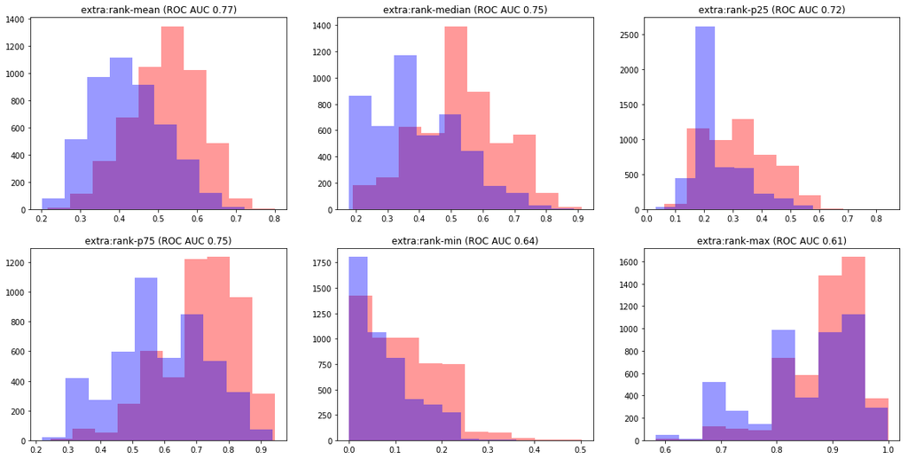

```python
rank_fts = [f for f in df.columns.values if f.startswith('extra:rank-')]

plt.figure(figsize=(20, 10))

for i, f in enumerate(rank_fts):
    plt.subplot(2, 3, i + 1)
    plt.title('%s (ROC AUC %.2f)' % (f, roc_auc_score(y[not_mising], df[f].loc[not_mising].values)))
    plt.hist(df[f].loc[not_mising].values[(y == 1)[not_mising]], color='red', alpha=0.4)
    plt.hist(df[f].loc[not_mising].values[(y == 0)[not_mising]], color='blue', alpha=0.4)
plt.show()
```

### Feature Engineering: Pairwise Interactions

Most interpretable models (e.g., Decision Trees, Logistic Regression, Scorecards) do not consider the interaction between features. Thus, we extracted features that account for pairwise interactions between monotonic features. Namely:

- The relative ordering of features (i.e., $rank(A) < rank(B)$, $rank(A) > rank(B)$)
- The minimum and maximum of the relative values (e.g., $min(rank(A), rank(B)$)
- Arithmetic aggregation of the relative values (i.e., addition and product of features).

We chose these operators since they preserve monotonocity and can be easily replicated by a human expert. Below, we show the predicitve performance of these features.

```python
inter_fts = [f for f in df.columns.values if f.startswith('min') or
             f.startswith('max') or f.startswith('prod') or f.startswith('sum') or
             f.startswith('>') or f.startswith('<')]

results = []

for f in inter_fts:
    values = df[f].loc[not_mising].values

    if len(set(values)) != 2:
        continue

    f1, f2 = f.split(',')
    f1 = f1[f1.index('(') +  1:]
    f2 = f2[:-1]
    results.append((f1, f[0], f2, accuracy_score(y[not_mising], values)))

results = pd.DataFrame(results, columns=['Feature 1', 'Op', 'Feature 2', 'Accuracy'])
results.sort_values(by='Accuracy', ascending=False, inplace=True)
results
```

|  | Feature 1 | Op | Feature 2 | Accuracy |
| --- | --- | --- | --- | --- |
| 1 | rank:MSinceMostRecentDelq | < | rank:NetFractionRevolvingBurden | 0.65 |
| 0 | rank:AverageMInFile | > | rank:MSinceMostRecentDelq | 0.63 |
| 2 | rank:MSinceMostRecentDelq | < | rank:NumBank2NatlTradesWHighUtilization | 0.63 |
| 4 | rank:MSinceMostRecentDelq | < | rank:MaxDelq2PublicRecLast12M | 0.62 |
| 3 | rank:MSinceMostRecentDelq | < | rank:MaxDelqEver | 0.61 |

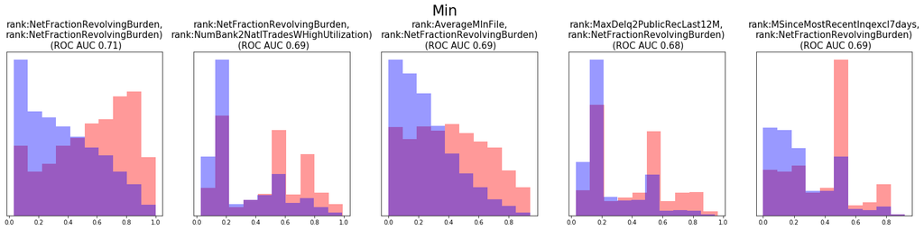

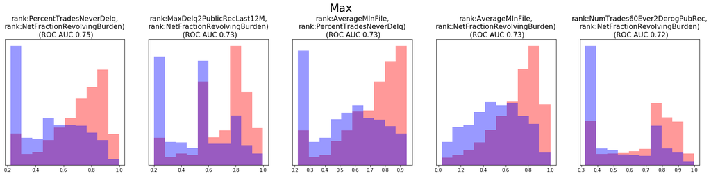

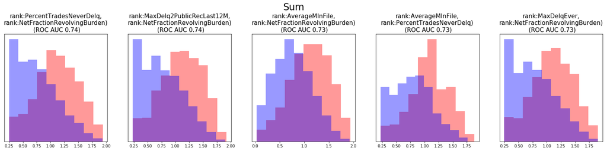

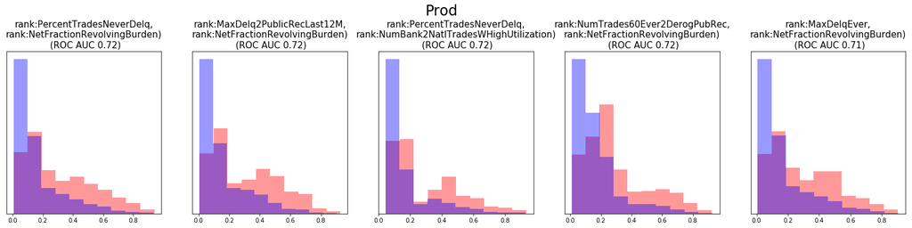

```python
for op in ['min', 'max', 'sum', 'prod']:
    cc = 1
    plt.figure(figsize=(27, 5))

    plt.suptitle(op.capitalize(), y=1.1, fontsize=24)
    for f in inter_fts:
        if not f.startswith(op):
            continue

        values = df[f].loc[not_mising].values

        plt.subplot(1, 5, cc)
        plt.hist(values[y[not_mising] == 1], color='red', alpha=0.4)
        plt.hist(values[y[not_mising] == 0], color='blue', alpha=0.4)
        plt.title(f[f.index('(') + 1:].replace(',', ',\n') +
                  '\n (ROC AUC %.2f)' % roc_auc_score(y[not_mising], values), fontsize=15)
        plt.yticks([])
        cc += 1
    plt.show()
```

# In-model Interpretability

Our final solution consists of an ensemble of three models with different degrees of interpretability.

- Scorecard.
- Random Forest.
- Deep Neural Network.

We follow our previously proposed framework for the objective analysis of interpretability that consists on studying the "3 Cs of interpretability": correctness, completeness and compactness. Further details about our work, can be found in [2]

We decompose the analysis of the in-model interpretability on three blocks, depending on the type of model we use.

## Scorecards

- **Binning:** while typical strategies to bin features consist of equal-frequency and equal-width which do not take into account the supervised labels, we used the decision thresholds of a Decision Tree to decide the bins. We limited the number of bins to 20.
- **Sparsity:** we used differential-coding [3] for the binning and $L_1$ regularization to ensure a sparse number of scores.
- **Monotonicity:** we added a non-negative constraint to the scores associated to monotonic features. Since we are using differential-coding [3], adding this constraint to the scores ensures monotonicity.

In the image below, we show the most important features ordered by average impact. Reddish colors contribute to rejection whereas blueish contribute to acceptance. The colorbar was scaled to the percentile of the value in the feature domain.

As can be seen in the image, the weights follow the monotonic constraints and, in most cases, the number of bins (different colors) per features is small (3-6 in most cases), leading to a simple model.

```python
model = Scorecard(config, path='scorecard-global.h5', verbose=0)
model.fit(df.iloc[not_mising], y[not_mising])
None
```

```
Loading weights
Done.
```

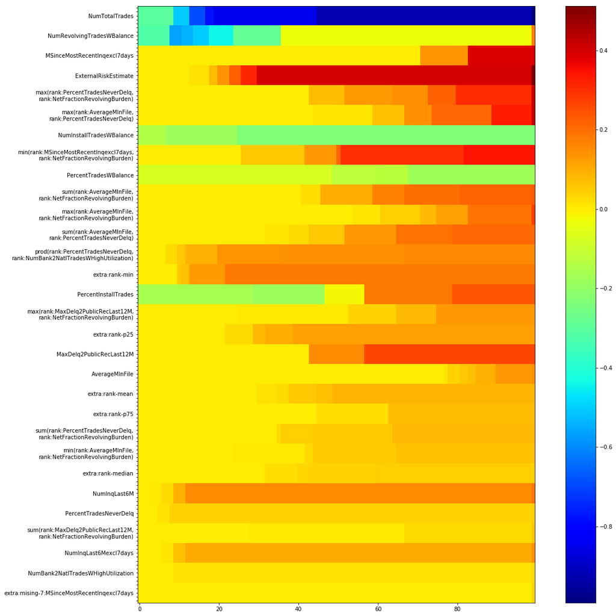

```python
ft_impact = []
global_ft_weight = model.output_layer.get_weights()[0].ravel()

for i, f in enumerate(model.all_features):
    fweight = model.all_bin_scores[i].get_weights()[0].ravel()
    fweight = fweight.copy()

    df_expected_value = np.asarray(model.apply_binning(df, f))
    df_expected_value = (df_expected_value * fweight[np.newaxis]).sum(axis=1)
    df_expected_value = df_expected_value.mean()

    next_impact = abs(df_expected_value * global_ft_weight[i])

    ft_impact.append((-next_impact, f, i))

heatmap = np.zeros((len(model.all_features), 100))

ft_impact = sorted(ft_impact)

valid = []
for idx_, (imp, f, i) in enumerate(ft_impact):
    fweight = model.all_bin_scores[i].get_weights()[0].ravel()
    orig_weights = fweight.copy()

    fweight = np.cumsum(fweight)
    fweight = [fweight[0]] + list(fweight)
    binning, _ = zip(*model.binning[f])

    binning = list(binning) + [df[f].max()]
    binning[0] = df[f].min()

    df_expected_value = np.asarray(model.apply_binning(df, f))
    df_expected_value = (df_expected_value * orig_weights[np.newaxis]).sum(axis=1)
    df_expected_value = df_expected_value.mean()

    values = df[f].values.astype(np.float)
    progress = np.linspace(0, 1, 100)
    progress = values.min() + progress * (values.max() - values.min())
    score = np.asarray([global_ft_weight[i] * np.asarray(fweight)[np.asarray(binning) <= p][-1] for p in progress])

    heatmap[idx_] = score
    valid.append(np.abs(score).max() > 1e-3)

ticks = [f[1] for f, v in zip(ft_impact, valid) if v]

N = 5
rpt = np.repeat(np.arange(len(ticks)), N)
img_ = heatmap[rpt]
valid_ = np.asarray(valid)[rpt]
ticks = [ticks[i // N].replace(',', ',\n') if i % N == N // 2 else '' for i in range(len(img_))]

M = 30 * N

ax = plt.figure(figsize=(20, 20))
im = plt.imshow(img_[valid_][: M], cmap='jet')
plt.yticks(np.arange(len(ticks))[: M], ticks[: M])
plt.colorbar(im)
plt.show()
```

## Random Forest

Although Random Forests are not considered interpretable models in general, individual trees within the ensemble are interpretable (given a limited depth). Therefore, we can train a large ensemble and pick the explanation from those estimators that agree with the overall decision.

The final explanation is chosen from the path from the source to the tree leaf with highest correctness (i.e., purity). This criterion follows the previously proposed framework (i.e., the 3 Cs of interpretability), considering completeness and compactness as fixed given limited-size trees. We limited the depth of the individual estimators to 4, being a good tradeoff between predictive performance and model interpretability.

This framework allows to generate diverse and complementary explanations without compromising the interpretability of a single decision tree.

Below, we show an illustrative example of a tree trained without the intrinsic randomness of a Random Forest.

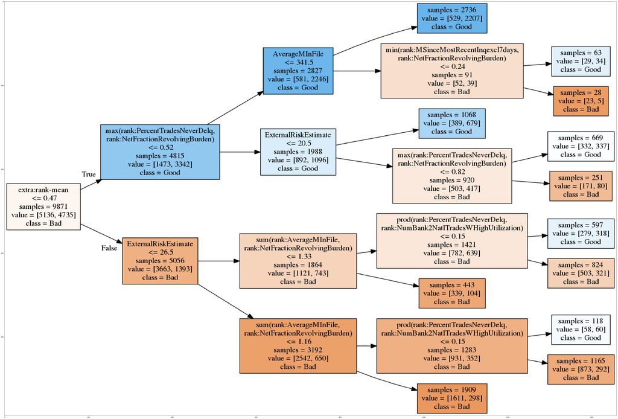

```python
dec_tree = DecisionTreeExplanation(config, criterion='gini', max_depth=4)
dec_tree.fit(df.iloc[not_mising], 1-y[not_mising])

dot_data = export_graphviz(dec_tree.estimator, out_file='f.dot',
                           feature_names=[x.replace(',', ',\n') + '\n' for x in dec_tree.all_features],
                           class_names=['Good', 'Bad'][::-1], precision=2, filled=True,
                           impurity=False,
                           rotate=True)

system('dot -Tpng f.dot -o full-tree.png; rm f.dot')

img = Image.open('full-tree.png')

plt.figure(figsize=(80, 80))
plt.imshow(img)
plt.show()
```

Also, we show the global relevance of the features. We can observe that, as exptected, the most important feature is the External Risk Estimate (17%), inmediately followed by the average position of the client in the population regarding monotonic features (12%).

```python
from sklearn.ensemble import RandomForestClassifier

pd.set_option('precision', 2)

rf = RandomForestClassifier(100, max_depth=4, random_state=42, n_jobs=-1)
rf.fit(df.values, y)

relevance, ft_name = zip(*list(sorted(zip(rf.feature_importances_, df.columns.values))))
relevance = np.asarray(relevance)[:, np.newaxis]
relevance *= 100
ordered_fts = pd.DataFrame(relevance, index=ft_name, columns=('Relevance',))
ordered_fts.sort_values(by='Relevance', inplace=True, ascending=False)
ordered_fts = ordered_fts.loc[ordered_fts.Relevance > 0]
ordered_fts = ordered_fts.head(10)
ordered_fts = pd.concat([ordered_fts,
                         pd.DataFrame(np.asarray([float(100 - ordered_fts.sum())])[:, np.newaxis],
                                      columns=('Relevance',), index=['Other features'])])
ordered_fts
```

|  | Relevance |
| --- | --- |
| ExternalRiskEstimate | 17.96 |
| extra:rank-mean | 12.95 |
| extra:rank-median | 9.12 |
| sum(rank:PercentTradesNeverDelq,rank:NetFractionRevolvingBurden) | 5.56 |
| sum(rank:MaxDelq2PublicRecLast12M,rank:NetFractionRevolvingBurden) | 4.82 |
| extra:rank-p75 | 4.59 |
| max(rank:PercentTradesNeverDelq,rank:NetFractionRevolvingBurden) | 4.48 |
| max(rank:NumTrades60Ever2DerogPubRec,rank:NetFractionRevolvingBurden) | 3.81 |
| max(rank:MaxDelq2PublicRecLast12M,rank:NetFractionRevolvingBurden) | 3.61 |
| extra:rank-p25 | 3.43 |
| Other features | 29.67 |

## Nearest Neighbors by Deep Neural Networks

Humans are prone to explain by comparison. Thus, case-based reasoning is a traditional way of explaining decisions. However, choosing the right distance may be crucial on finding relevant examples. Namely, Euclidean and Manhattan distances may be suboptimal on finding good candidates for comparison.

In this sense, while Deep Neural Networks are considered as blackbox models in general, they are capable of learning semantic representations that preserve relevant properties in terms of sample similarity as has been observed in word and visual embeddings.

We extract two types of explanations from DNN:

- **Similar:** the most similar example in the latent space from the same class.
- **Opponent:** the most similar example in the latent space from the opposite class.

Moreover, in order to facilitate the comparison, we include a sensitivity analysis of which features make them similar or different, respectively.

The architecture of our Deep Neural Network has two streams. One stream without constraints for non-monotonic features and one stream with non-negative constraints for monotonic feautes. Finally, both streams are merged (with further monotonic layers) to produce the final latent space. The following figure illustrates the architecture:

[figure not shown]

As the plots below demonstrate, the embeddings obtained by the DNN are able to organize the clients according to their probability of rejection, contrarily to the distribution observed in the original feature space and in the extended space after feature engineering.

```python
from models.joint import JointExplanations
dnn = JointExplanations(config, dense_width=5, dense_unconstrained_num=1,
                        dense_monotonic_num=1, dense_joint_num=1,
                        epochs=100, path='final_dnn.h5',
                        include_coverage=False,
                        verbose=0
                       )
dnn = dnn.fit(df.iloc[not_mising], y[not_mising])
```

```
Train on 7896 samples, validate on 1975 samples
 - 1s - loss: 0.6513 - acc: 0.6455 - val_loss: 0.5907 - val_acc: 0.7109

Epoch 00001: val_loss improved from inf to 0.59068, saving model to final_dnn.h5
 - 0s - loss: 0.6262 - acc: 0.6700 - val_loss: 0.5809 - val_acc: 0.7195

Epoch 00002: val_loss improved from 0.59068 to 0.58095, saving model to final_dnn.h5
 - 0s - loss: 0.6259 - acc: 0.6797 - val_loss: 0.5740 - val_acc: 0.7251

Epoch 00003: val_loss improved from 0.58095 to 0.57399, saving model to final_dnn.h5
 - 0s - loss: 0.6188 - acc: 0.6817 - val_loss: 0.5700 - val_acc: 0.7291

Epoch 00004: val_loss improved from 0.57399 to 0.56996, saving model to final_dnn.h5
 - 0s - loss: 0.6102 - acc: 0.6960 - val_loss: 0.5665 - val_acc: 0.7332

Epoch 00005: val_loss improved from 0.56996 to 0.56648, saving model to final_dnn.h5
 - 0s - loss: 0.6121 - acc: 0.6977 - val_loss: 0.5642 - val_acc: 0.7316

Epoch 00006: val_loss improved from 0.56648 to 0.56420, saving model to final_dnn.h5
 - 0s - loss: 0.6069 - acc: 0.6990 - val_loss: 0.5628 - val_acc: 0.7286

Epoch 00007: val_loss improved from 0.56420 to 0.56279, saving model to final_dnn.h5
 - 0s - loss: 0.6012 - acc: 0.7052 - val_loss: 0.5618 - val_acc: 0.7301

Epoch 00008: val_loss improved from 0.56279 to 0.56181, saving model to final_dnn.h5
 - 0s - loss: 0.5999 - acc: 0.7061 - val_loss: 0.5610 - val_acc: 0.7316

Epoch 00009: val_loss improved from 0.56181 to 0.56104, saving model to final_dnn.h5
 - 0s - loss: 0.5978 - acc: 0.7109 - val_loss: 0.5598 - val_acc: 0.7337

Epoch 00010: val_loss improved from 0.56104 to 0.55975, saving model to final_dnn.h5
 - 0s - loss: 0.5987 - acc: 0.7120 - val_loss: 0.5588 - val_acc: 0.7352

Epoch 00011: val_loss improved from 0.55975 to 0.55882, saving model to final_dnn.h5
 - 0s - loss: 0.5928 - acc: 0.7159 - val_loss: 0.5577 - val_acc: 0.7327

Epoch 00012: val_loss improved from 0.55882 to 0.55771, saving model to final_dnn.h5
 - 0s - loss: 0.5938 - acc: 0.7148 - val_loss: 0.5568 - val_acc: 0.7342

Epoch 00013: val_loss improved from 0.55771 to 0.55681, saving model to final_dnn.h5
```

[output cut: 246 more lines]

```
 - 0s - loss: 0.5678 - acc: 0.7296 - val_loss: 0.5462 - val_acc: 0.7428

Epoch 00096: val_loss did not improve
 - 0s - loss: 0.5704 - acc: 0.7275 - val_loss: 0.5456 - val_acc: 0.7473

Epoch 00097: val_loss did not improve
 - 0s - loss: 0.5730 - acc: 0.7329 - val_loss: 0.5457 - val_acc: 0.7438

Epoch 00098: val_loss did not improve
 - 0s - loss: 0.5687 - acc: 0.7297 - val_loss: 0.5457 - val_acc: 0.7433

Epoch 00099: val_loss did not improve
 - 0s - loss: 0.5737 - acc: 0.7249 - val_loss: 0.5461 - val_acc: 0.7448

Epoch 00100: val_loss did not improve
```

```python
embeddings = dnn.embedding_model.predict(df[dnn.all_features])
```

```python
orig_fts = [f for f in model.all_features if not f.startswith('extra') and 'rank' not in f]
```

```python
from sklearn.manifold import TSNE

iter_ = 1000
e_index = np.arange(len(df))
np.random.shuffle(e_index)
e_index = e_index[: 1000]

emb_orig = TSNE(2, random_state=42, n_iter=iter_).fit_transform(df[orig_fts].values[e_index])
emb_ft_eng = TSNE(2, random_state=42, n_iter=iter_).fit_transform(df[model.all_features].values[e_index])
emb_dnn = TSNE(2, random_state=42, n_iter=iter_).fit_transform(embeddings[e_index])
```

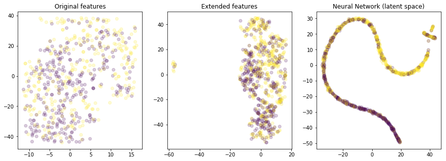

```python
from mpl_toolkits import mplot3d

plt.figure(figsize=(15, 5))

mask_orig = np.ones(emb_orig.shape[0], dtype=np.bool)
mask_ft_eng = np.ones(emb_ft_eng.shape[0], dtype=np.bool)
for ch in range(emb_orig.shape[1]):
    mask_orig = mask_orig & (emb_orig[:, ch] >= np.percentile(emb_orig[:, ch], 10))
    mask_orig = mask_orig & (emb_orig[:, ch] <= np.percentile(emb_orig[:, ch], 90))

    mask_ft_eng = mask_ft_eng & (emb_ft_eng[:, ch] >= np.percentile(emb_ft_eng[:, ch], 5))
    mask_ft_eng = mask_ft_eng & (emb_ft_eng[:, ch] <= np.percentile(emb_ft_eng[:, ch], 95))

plt.subplot(1, 3, 1)
plt.scatter(emb_orig[mask_orig, 0], emb_orig[mask_orig, 1], c=y[e_index][mask_orig], alpha=0.2)
plt.title('Original features')

plt.subplot(1, 3, 2)
plt.scatter(emb_ft_eng[mask_ft_eng, 0], emb_orig[mask_ft_eng, 1], c=y[e_index][mask_ft_eng], alpha=0.2)
plt.title('Extended features')

plt.subplot(1, 3, 3)
plt.scatter(emb_dnn[:, 0], emb_dnn[:, 1], c=y[e_index], alpha=0.2)
plt.title('Neural Network (latent space)')

plt.show()
```

# Post-model Intepretability

To improve the completeness (replicability) and simplicity of the explanations we simplified the models a posteriori.

- **Decision Trees:** pruning of branches that did not lead to further class refinement.
- **Scorecards:** building rules by merging neighboring bins that are monotonic on the decision for a given lcoal sample.

# Conclusions

As part of this work, we addressed the three main forms of interpretability in Machine Learning (pre, in, and post-model) [2].

We covered all the major trends in interpretability, from white-box models with regularization, to monotonic constraints, to sensitivity analysis.

The core idea of the proposed solution is to satisfy the curiosity of decision makers by providing complentary explanations such as the ones obtained from an ensemble of trees, a scorecard, and similar/opponent examples. An explanation is valuable as long as it is able to convince the audience, being a core property, the expansion and diversity of the types of insights the model can provide.

# References

[1] Been Kim and Finale Doshi-Velez. *"Interpretable Machine Learning: The fuss, the concrete and the questions"* ICML Tutorial on Interpretable Machine Learning (2017).

[2] Wilson Silva, Kelwin Fernandes and Jaime S. Cardoso *"Towards complementary explanations using Deep Neural Networks."* Workshop on Interpretability of Machine Intelligence in Medical Image Computing at MICCAI (2018). [(link)](https://tinyurl.com/wilsonMICCAI2018)

[3] Pedro Silva and Jaime S. Cardoso. *"Differential Scorecards for Binary and Ordinal Data."* Intelligent Data Analysis 19.6 (2015): 1391-1408.